# analytics-olympiad-2023-eda

### Create a machine learning models to determine the likelihood of a customer defaulting on a loan based on the credit history, payment behaviour, and account details.

### Import the necessary packages

```python
import numpy as np # linear algebra
import pandas as pd # data processing, CSV file I/O (e.g. pd.read_csv)
import seaborn as sns # visualization
from matplotlib import pyplot as plt # visualization
%matplotlib inline
import warnings
warnings.filterwarnings("ignore")
import re

from sklearn.preprocessing import LabelEncoder
from sklearn.feature_selection import SelectKBest, SelectPercentile, mutual_info_classif
```

### Import train and test dataset

```python
train=pd.read_csv("/kaggle/input/analytics-olympiad-2023/train.csv")
test=pd.read_csv("/kaggle/input/analytics-olympiad-2023/test.csv")
```

### Structure of the train and test dataset

```python
train.info()
```

```
<class 'pandas.core.frame.DataFrame'>
RangeIndex: 1106674 entries, 0 to 1106673
Data columns (total 62 columns):
 #   Column                              Non-Null Count    Dtype
---  ------                              --------------    -----
 0   customer_id                         1106674 non-null  object
 1   firstname                           1106674 non-null  object
 2   lastname                            1106674 non-null  object
 3   record_number                       1106674 non-null  int64
 4   days_since_opened                   1106674 non-null  int64
 5   days_since_confirmed                1106674 non-null  int64
 6   primary_term                        1106674 non-null  int64
 7   final_term                          1106674 non-null  int64
 8   days_till_primary_close             1106674 non-null  int64
 9   days_till_final_close               1106674 non-null  int64
```

[output cut: 54 more lines]

#### The above information shows that there are 1106674 data entries and 62 columns.

```python
test.info()
```

```
<class 'pandas.core.frame.DataFrame'>
RangeIndex: 474289 entries, 0 to 474288
Data columns (total 60 columns):
 #   Column                              Non-Null Count   Dtype
---  ------                              --------------   -----
 0   customer_id                         474289 non-null  object
 1   firstname                           474289 non-null  object
 2   lastname                            474289 non-null  object
 3   record_number                       474289 non-null  int64
 4   days_since_opened                   474289 non-null  int64
 5   days_since_confirmed                474289 non-null  int64
 6   primary_term                        474289 non-null  int64
 7   final_term                          474289 non-null  int64
 8   days_till_primary_close             474289 non-null  int64
 9   days_till_final_close               474289 non-null  int64
```

[output cut: 52 more lines]

#### The above information shows that there are 474289 data entries and 60 columns.

### Let's see is there any missing values in train and test dataset by column wise.

```python
def missing_val_cols(df,plot=True):
    miss_df=pd.DataFrame(columns=['column_name','missing_value_count'])
    for col in df.columns.values:
        if df[col].isnull().sum()>0:
            miss_df.loc[len(miss_df)]=[col, df[col].isnull().sum()]
        else:
            pass
    if plot:
        _=sns.barplot(data=miss_df,y='column_name',x='missing_value_count');
    else:
        return miss_df
```

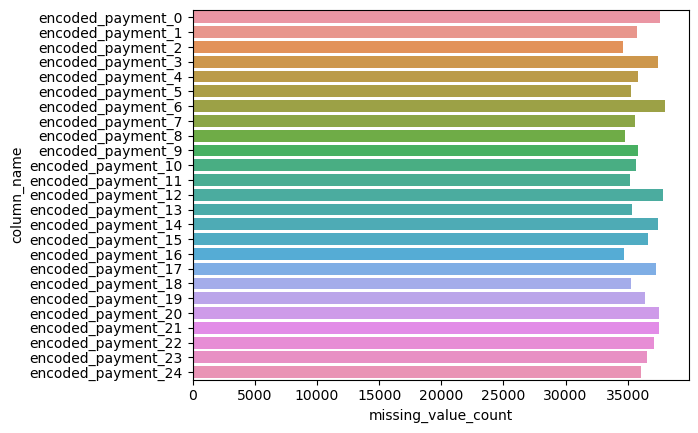

```python
missing_val_cols(train)
```

```python
missing_val_cols(train,plot=False)
```

|  | column_name | missing_value_count |
| --- | --- | --- |
| 0 | encoded_payment_0 | 37619 |
| 1 | encoded_payment_1 | 35744 |
| 2 | encoded_payment_2 | 34612 |
| 3 | encoded_payment_3 | 37416 |
| 4 | encoded_payment_4 | 35840 |
| 5 | encoded_payment_5 | 35304 |
| 6 | encoded_payment_6 | 38019 |
| 7 | encoded_payment_7 | 35629 |
| 8 | encoded_payment_8 | 34762 |
| 9 | encoded_payment_9 | 35851 |
| 10 | encoded_payment_10 | 35635 |
| 11 | encoded_payment_11 | 35199 |
| 12 | encoded_payment_12 | 37808 |
| 13 | encoded_payment_13 | 35351 |
| 14 | encoded_payment_14 | 37459 |
| 15 | encoded_payment_15 | 36674 |
| 16 | encoded_payment_16 | 34712 |
| 17 | encoded_payment_17 | 37315 |
| 18 | encoded_payment_18 | 35268 |
| 19 | encoded_payment_19 | 36381 |
| 20 | encoded_payment_20 | 37519 |
| 21 | encoded_payment_21 | 37548 |
| 22 | encoded_payment_22 | 37155 |
| 23 | encoded_payment_23 | 36543 |
| 24 | encoded_payment_24 | 36045 |

#### The above plot and summary explains that in train dataset, the encoded payment category column has more missing values.

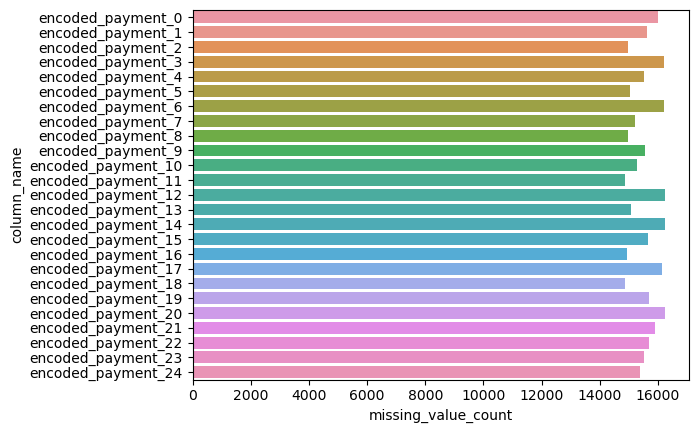

```python
missing_val_cols(test)
```

```python
missing_val_cols(train,plot=False)
```

|  | column_name | missing_value_count |
| --- | --- | --- |
| 0 | encoded_payment_0 | 37619 |
| 1 | encoded_payment_1 | 35744 |
| 2 | encoded_payment_2 | 34612 |
| 3 | encoded_payment_3 | 37416 |
| 4 | encoded_payment_4 | 35840 |
| 5 | encoded_payment_5 | 35304 |
| 6 | encoded_payment_6 | 38019 |
| 7 | encoded_payment_7 | 35629 |
| 8 | encoded_payment_8 | 34762 |
| 9 | encoded_payment_9 | 35851 |
| 10 | encoded_payment_10 | 35635 |
| 11 | encoded_payment_11 | 35199 |
| 12 | encoded_payment_12 | 37808 |
| 13 | encoded_payment_13 | 35351 |
| 14 | encoded_payment_14 | 37459 |
| 15 | encoded_payment_15 | 36674 |
| 16 | encoded_payment_16 | 34712 |
| 17 | encoded_payment_17 | 37315 |
| 18 | encoded_payment_18 | 35268 |
| 19 | encoded_payment_19 | 36381 |
| 20 | encoded_payment_20 | 37519 |
| 21 | encoded_payment_21 | 37548 |
| 22 | encoded_payment_22 | 37155 |
| 23 | encoded_payment_23 | 36543 |
| 24 | encoded_payment_24 | 36045 |

### Let's see the glimpse of train dataset

```python
train.head(2)
```

|  | customer_id | firstname | lastname | record_number | days_since_opened | days_since_confirmed | primary_term | final_term | days_till_primary_close | days_till_final_close | ... | encoded_payment_21 | encoded_payment_22 | encoded_payment_23 | encoded_payment_24 | encoded_loans_account_holder_type | encoded_loans_credit_status | encoded_loans_credit_type | encoded_loans_account_currency | primary_close_flag | final_close_flag |
| --- | --- | --- | --- | --- | --- | --- | --- | --- | --- | --- | --- | --- | --- | --- | --- | --- | --- | --- | --- | --- | --- |
| 0 | 4814dfa2-45a8-46b9-8102-98ecbbec2d2a | Navya | Vasa | 7 | 10 | 8 | 12 | 10 | 13 | 5 | ... | 0.0 | 1.0 | 3.0 | 4.0 | 1 | 3 | 4 | 1 | 0 | 0 |
| 1 | bb0abe41-cc89-4a1d-bb1c-48bd212ae00d | Azad | Warrior | 5 | 15 | 6 | 7 | 6 | 9 | 1 | ... | 3.0 | 3.0 | 3.0 | 4.0 | 1 | 3 | 4 | 1 | 0 | 0 |

2 rows × 62 columns

### Let's create a function to display the catgeorical column level counts.

```python
def count_plot(df,col,rot=None,switchax=None,size=(8,6),title=''):
    _=plt.figure(figsize=size)
    if switchax:
        _=sns.countplot(y=df[col],order=df[col].value_counts().index);
        _=plt.title(title,fontsize=25)
        _=plt.ylabel(col,fontsize=20)
        _=plt.yticks(fontsize=14,rotation=rot)

    else:
        _=sns.countplot(x=df[col],order=df[col].value_counts().index);
        _=plt.title(title,fontsize=25)
        _=plt.xlabel(col,fontsize=20)
        _=plt.xticks(fontsize=14,rotation=rot)
```

### To predict the likelihood of customer default, the model has to predict two outcome variables.

### Let's see the primary_close_flag target distribution.

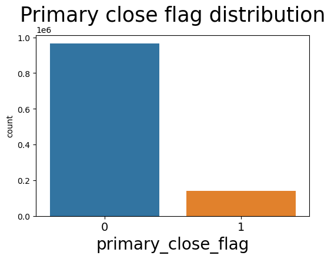

```python
count_plot(train,'primary_close_flag',size=(6,4), title="primary close flag Distribution".capitalize())
```

```python
train['primary_close_flag'].value_counts()
```

```
0    964720
1    141954
Name: primary_close_flag, dtype: int64
```

### The above plot and summary explain that there is an imbalance between the classes.

### Let's see the final_close_flag target distribution.

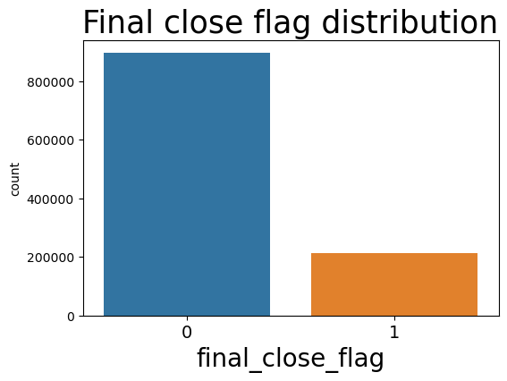

```python
count_plot(train,'final_close_flag',size=(6,4), title="final close flag Distribution".capitalize())
```

```python
train['final_close_flag'].value_counts()
```

```
0    895249
1    211425
Name: final_close_flag, dtype: int64
```

### The above plot and summary explain that there is an imbalance between the classes.

### Both primary_close_flag and final_close_flag target classes are biased to one class.

### Let's explore credit card information related features.

- record_number
- days_since_opened
- days_since_confirmed
- primary_term
- final_term
- days_till_primary_close
- days_till_final_close
- loans_credit_limit
- loans_next_payment_summary
- loans_outstanding_balance
- loans_max_overdue_amount
- loans_credit_cost_rate

### Let's see number of unique categories in credit card information related features.

```python
for i,col  in enumerate(train.columns[3:15]):
    print(f"{col}:{train[col].nunique()}")
```

[output not shown]

### Let's examine how the primary close flag target feature is distributed in relation to the credit card information-related features.

```python
def subplots(df,columns_list,target_name,n_row,n_col,size=(15,25)):
    fig=plt.subplots(figsize=size)
    for i,n  in enumerate(columns_list):
        _=plt.subplot(n_row,n_col,i+1)
        _=sns.countplot(train,x=n,hue=target_name)
        _=plt.title(f"{n} wise\n{target_name} distribution",fontsize=15)
        _=plt.ylabel("")
        _=plt.tight_layout()
    plt.show()
```

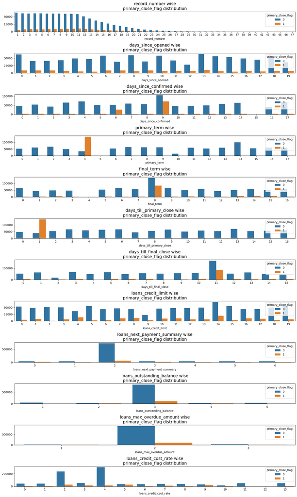

```python
subplots(train,train.columns[3:15],'primary_close_flag',12,1)
```

### Let's examine how the final close flag target feature is distributed in relation to the credit card information-related features.

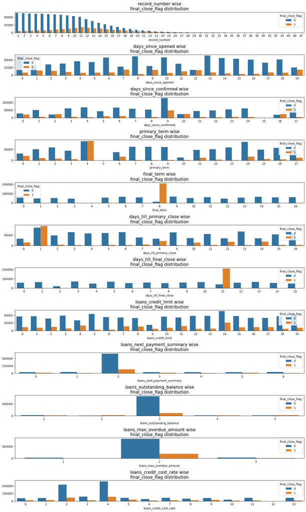

```python
subplots(train,train.columns[3:15],'final_close_flag',12,1)
```

### Let's explore loan overdue information related features.

- loans_within_5_days
- loans_within_5_to_30_days
- loans_within_30_to_60_days
- loans_within_60_to_90_days
- loans_over_90_days
- is_zero_loans_within_5_days
- is_zero_loans_within_5_to_30_days
- is_zero_loans_within_30_to_60_days
- is_zero_loans_within_60_to_90_days
- is_zero_loans_over_90_days

### Let's see number of unique categories in loan overdue information related features.

```python
for i,col  in enumerate(train.columns[15:25]):
    print(f"{col}:{train[col].nunique()}")
```

[output not shown]

### Let's examine how the primary close flag target feature is distributed in relation to the loan overdue information-related features.

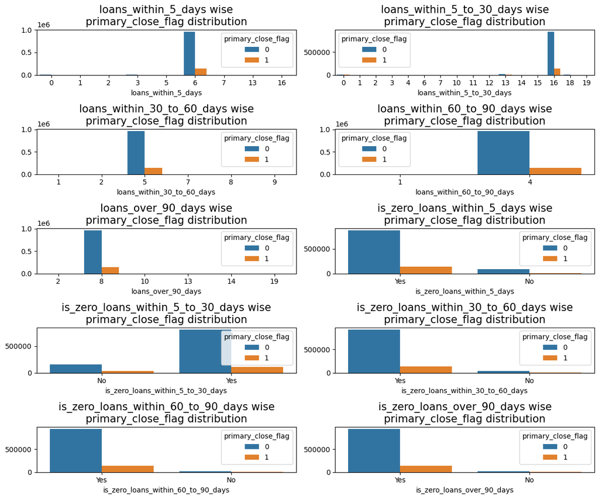

```python
subplots(train,train.columns[15:25],'primary_close_flag',5,2,size=(12,10))
```

### Let's examine how the final close flag target feature is distributed in relation to the loan overdue information-related features.

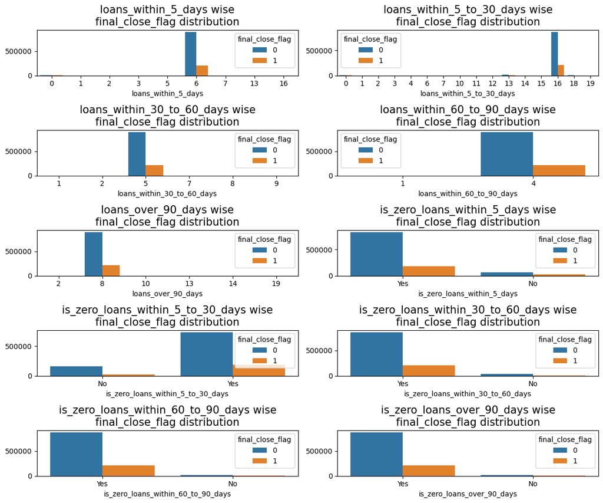

```python
subplots(train,train.columns[15:25],'final_close_flag',5,2,size=(12,10))
```

### Let's explore credit utilization and limit information related features.

- utilization
- over_limit_count
- max_over_limit_count
- is_zero_utilization
- is_zero_over_limit_count
- is_zero_max_over_limit_count

### Let's see number of unique categories in credit utilization and limit information related features.

```python
for i,col  in enumerate(train.columns[25:31]):
    print(f"{col}:{train[col].nunique()}")
```

```
utilization:20
over_limit_count:20
max_over_limit_count:20
is_zero_utilization:2
is_zero_over_limit_count:2
is_zero_max_over_limit_count:2
```

### Let's examine how the primary close flag target feature is distributed in relation to the credit utilization and limit information-related features.

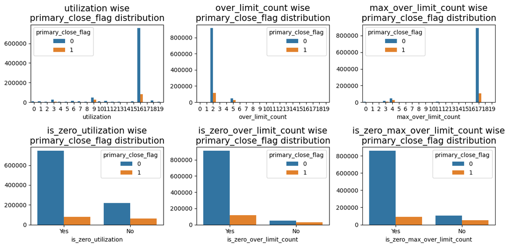

```python
subplots(train,train.columns[25:31],'primary_close_flag',2,3,size=(12,6))
```

### Let's examine how the final close flag target feature is distributed in relation to the credit utilization and limit information-related features.

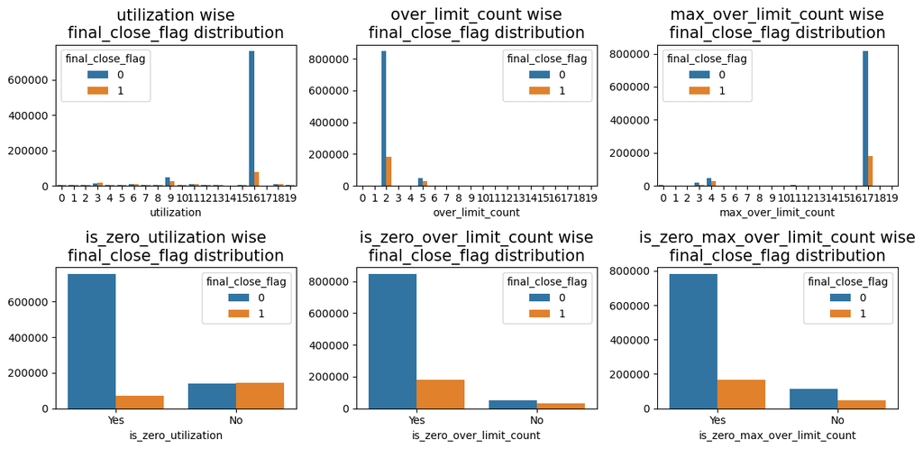

```python
subplots(train,train.columns[25:31],'final_close_flag',2,3,size=(12,6))
```

### Let's explore encoded features.

- encoded_payment_0
- encoded_payment_1
- encoded_payment_2
- encoded_payment_3
- encoded_payment_4
- encoded_payment_5
- encoded_payment_6
- encoded_payment_7
- encoded_payment_8
- encoded_payment_9
- encoded_payment_10
- encoded_payment_11
- encoded_payment_12
- encoded_payment_13
- encoded_payment_14
- encoded_payment_15
- encoded_payment_16
- encoded_payment_17
- encoded_payment_18
- encoded_payment_19
- encoded_payment_20
- encoded_payment_21
- encoded_payment_22
- encoded_payment_23
- encoded_payment_24
- encoded_loans_account_holder_type
- encoded_loans_credit_status
- encoded_loans_credit_type
- encoded_loans_account_currency

### Let's see number of unique categories in encoded features.

```python
for i,col  in enumerate(train.columns[31:60]):
    print(f"{col}:{train[col].nunique()}")
```

```
encoded_payment_0:4
encoded_payment_1:4
encoded_payment_2:4
encoded_payment_3:4
encoded_payment_4:4
encoded_payment_5:4
encoded_payment_6:4
encoded_payment_7:4
encoded_payment_8:4
encoded_payment_9:4
encoded_payment_10:4
encoded_payment_11:4
encoded_payment_12:4
encoded_payment_13:4
encoded_payment_14:4
encoded_payment_15:4
encoded_payment_16:4
encoded_payment_17:4
encoded_payment_18:4
encoded_payment_19:4
encoded_payment_20:4
encoded_payment_21:4
encoded_payment_22:4
encoded_payment_23:4
encoded_payment_24:4
encoded_loans_account_holder_type:7
encoded_loans_credit_status:7
encoded_loans_credit_type:8
encoded_loans_account_currency:4
```

### Let's examine how the primary close flag target feature is distributed in relation to the encoded features.

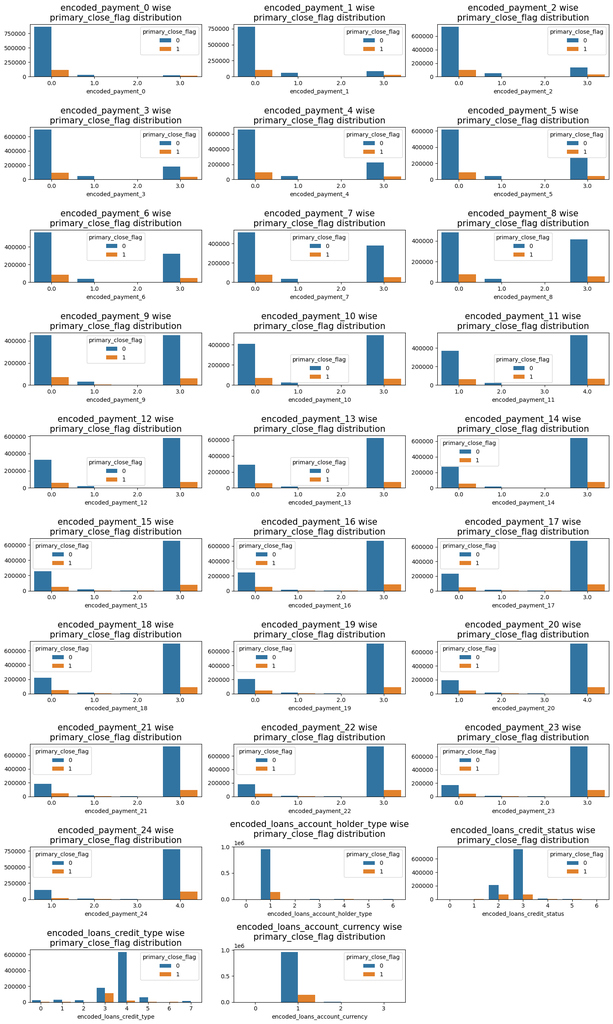

```python
subplots(train,train.columns[31:60],'primary_close_flag',10,3,size=(15,25))
```

### Let's examine how the final close flag target feature is distributed in relation to the encoded features.

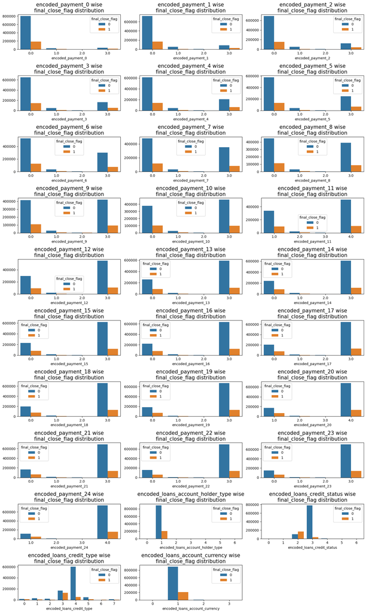

```python
subplots(train,train.columns[31:60],'final_close_flag',10,3,size=(15,25))
```

### Let's calculate the mutual information between the primary close flag target and independent features.

#### Mutual information ranges from 0 to positive infinity. The higher mutual information represents more shared information between the feature and the target.

```python
X=train.iloc[:,np.r_[3:60]]
y1=train['primary_close_flag']
y2=train['final_close_flag']
```

### Label encoding category columns

```python
lbl=LabelEncoder()

for col in X.select_dtypes(include='object').columns:
    X[col]=lbl.fit_transform(X[[col]])
```

### Fill null values.

```python
X=X.fillna(0)
```

### Mutual information classifier for primary_close_flag

```python
primary_close_flag_mi = mutual_info_classif(X, y1)
```

```python
primary_close_flag_mi_df=pd.DataFrame({'columns':X.columns.values,'mutual_info':primary_close_flag_mi})
primary_close_flag_mi_df=primary_close_flag_mi_df.sort_values('mutual_info',ascending=False)
```

### Mutual information for the target primary close flag

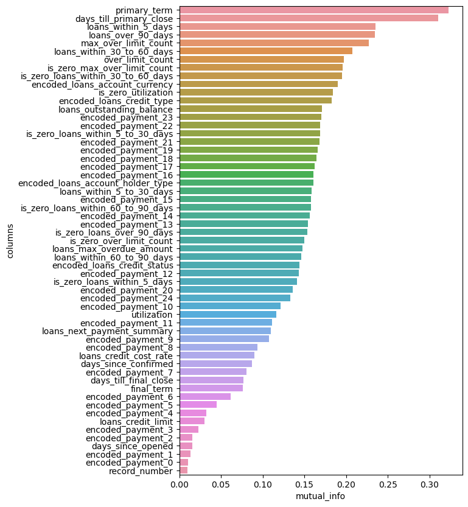

```python
_=plt.figure(figsize=(6,10))
sns.barplot(primary_close_flag_mi_df,y='columns',x='mutual_info');
```

### Let's calculate mutual information between the final close flag target and independent features.

### Mutual information classifier for final_close_flag

```python
final_close_flag_mi = mutual_info_classif(X, y2)
```

```python
final_close_flag_mi_df=pd.DataFrame({'columns':X.columns.values,'mutual_info':final_close_flag_mi})
final_close_flag_mi_df=final_close_flag_mi_df.sort_values('mutual_info',ascending=False)
```

### Mutual information for the target final close flag

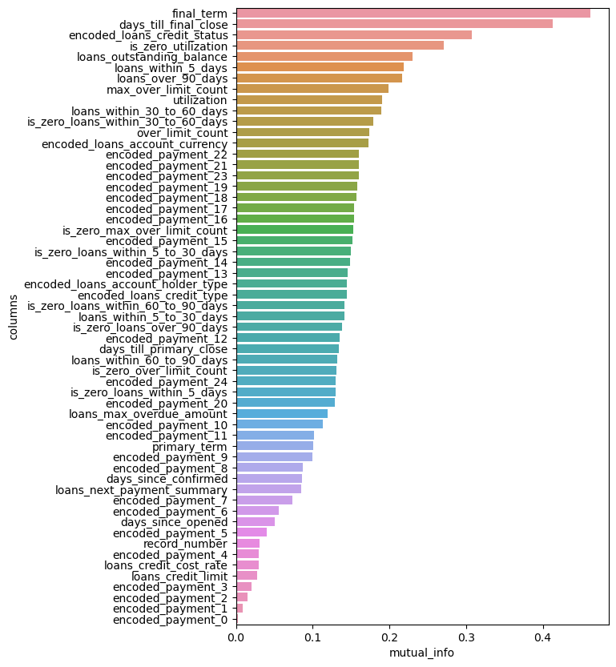

```python
_=plt.figure(figsize=(6,10))
sns.barplot(final_close_flag_mi_df,y='columns',x='mutual_info');
```

### Let's see multicollinearity between the independent features.

```python
from statsmodels.stats.outliers_influence import variance_inflation_factor

vif_data = pd.DataFrame()
vif_data["feature"] = X.columns

vif_data["VIF"] = [variance_inflation_factor(X.values, i) for i in range(len(X.columns))]
```

```python
vif_data=vif_data.sort_values('VIF',ascending=False)
```

### Features with greater than 5 VIF value

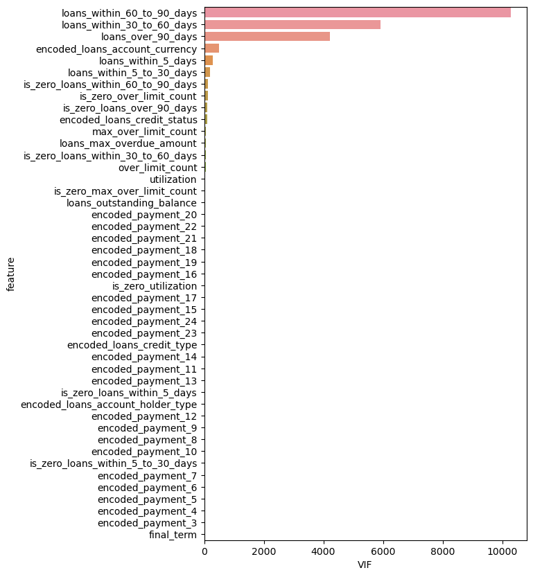

```python
_=plt.figure(figsize=(6,10))
sns.barplot(vif_data[vif_data['VIF']>5],y='feature',x='VIF');
```